# Machine Learning Project

Janina Lazo-Cruz

December 1, 2018

## Overview

Using data from accelerometers on the belt, forearm, arm, and dumbbell of 6 participants, this report aims to predict how well these participants do the exercise. The “classe” variable below pertains to the manner in which the participants conducted the exercise.

To begin with, cleaning up of the data sets provided must be executed.

```r
p.train <- createDataPartition(train$classe, p=0.7, list=FALSE)
s.train <- train[p.train, ]
s.test <- train[-p.train, ]
nil.var <- nearZeroVar(s.train)
s.train <- s.train[, -nil.var]
s.test <- s.test[, -nil.var]
non <- sapply(s.train, function(x) mean(is.na(x)))>0.95
s.train <- s.train[, non==FALSE]
s.test <- s.test[, non==FALSE]
s.train <- s.train[, -(1:5)]
s.test <- s.test[, -(1:5)]
dim(s.train)
```

```
## [1] 13737    54
```

```r
head(s.train)
```

```
##   num_window roll_belt pitch_belt yaw_belt total_accel_belt gyros_belt_x
## 2         11      1.41       8.07    -94.4                3         0.02
## 3         11      1.42       8.07    -94.4                3         0.00
## 4         12      1.48       8.05    -94.4                3         0.02
## 5         12      1.48       8.07    -94.4                3         0.02
## 6         12      1.45       8.06    -94.4                3         0.02
## 7         12      1.42       8.09    -94.4                3         0.02
##   gyros_belt_y gyros_belt_z accel_belt_x accel_belt_y accel_belt_z
## 2         0.00        -0.02          -22            4           22
## 3         0.00        -0.02          -20            5           23
## 4         0.00        -0.03          -22            3           21
## 5         0.02        -0.02          -21            2           24
## 6         0.00        -0.02          -21            4           21
## 7         0.00        -0.02          -22            3           21
##   magnet_belt_x magnet_belt_y magnet_belt_z roll_arm pitch_arm yaw_arm
```

[output cut: 69 more lines]

```r
dim(s.test)
```

```
## [1] 5885   54
```

```r
head(s.test)
```

```
##    num_window roll_belt pitch_belt yaw_belt total_accel_belt gyros_belt_x
## 1          11      1.41       8.07    -94.4                3         0.00
## 9          12      1.43       8.16    -94.4                3         0.02
## 10         12      1.45       8.17    -94.4                3         0.03
## 11         12      1.45       8.18    -94.4                3         0.03
## 15         12      1.45       8.20    -94.4                3         0.00
## 16         12      1.48       8.15    -94.4                3         0.00
##    gyros_belt_y gyros_belt_z accel_belt_x accel_belt_y accel_belt_z
## 1             0        -0.02          -21            4           22
## 9             0        -0.02          -20            2           24
## 10            0         0.00          -21            4           22
## 11            0        -0.02          -21            2           23
## 15            0         0.00          -21            2           22
## 16            0         0.00          -21            4           23
##    magnet_belt_x magnet_belt_y magnet_belt_z roll_arm pitch_arm yaw_arm
```

[output cut: 69 more lines]

## Correlate the Variables

Before creating any prediction models, the variables must be anaylzed by correlating them with each other. The plot generated by the function below allows to display the highly correlated variables displayed as dark colors.

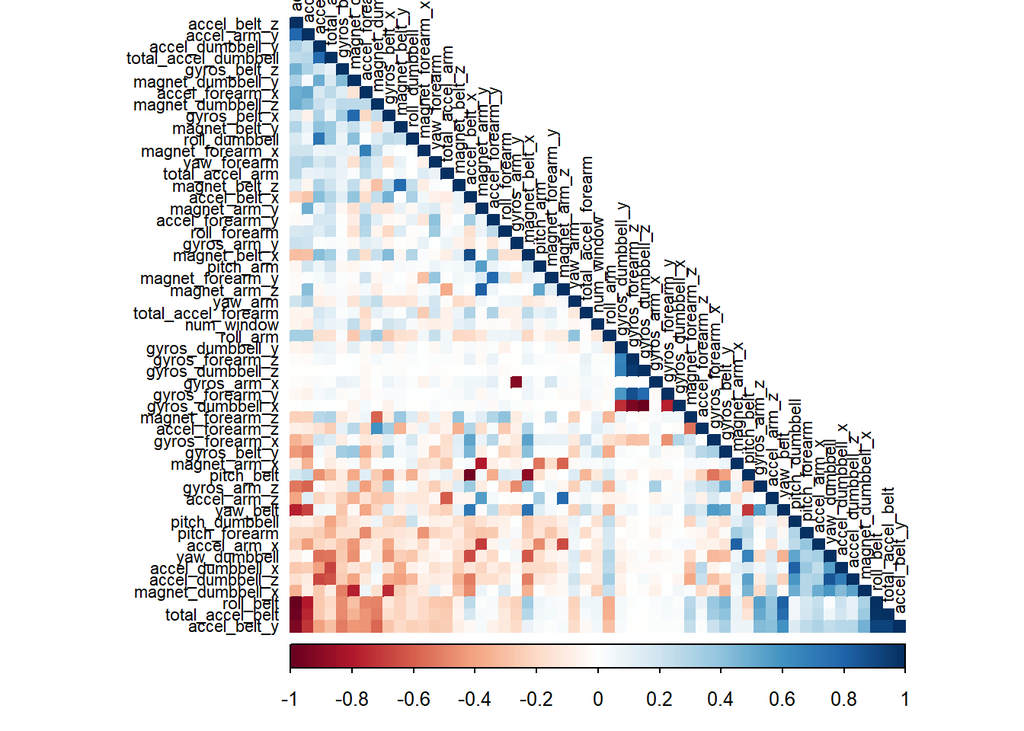

```r
cormat <- cor(s.train[, -54])
corrplot(cormat, order = "FPC", method = "color", type="lower",
         tl.cex=0.7, tl.col=rgb(0, 0, 0))
```

## Random Forest

First prediction model to create is Random Forest. The function below generates a plot, displaying the model’s accuracy within the title.

```r
set.seed(12345)
control <- trainControl(method="cv", number = 3, verboseIter = FALSE)
RF <- train(classe~., data=s.train, method="rf",
                          trControl=control)
RF$finalModel
```

```
##
## Call:
##  randomForest(x = x, y = y, mtry = param$mtry)
##                Type of random forest: classification
##                      Number of trees: 500
## No. of variables tried at each split: 27
##
##         OOB estimate of  error rate: 0.2%
## Confusion matrix:
##      A    B    C    D    E  class.error
## A 3904    1    0    0    1 0.0005120328
## B    6 2649    2    1    0 0.0033860045
## C    0    4 2391    1    0 0.0020868114
## D    0    0    7 2245    0 0.0031083481
## E    0    0    0    5 2520 0.0019801980
```

```r
predictRF <- predict(RF, newdata=s.test)
confmatRF <- confusionMatrix(predictRF, s.test$classe)
confmatRF
```

```
## Confusion Matrix and Statistics
##
##           Reference
## Prediction    A    B    C    D    E
##          A 1674    5    0    0    0
##          B    0 1133    4    0    0
##          C    0    1 1022    7    0
##          D    0    0    0  957    4
##          E    0    0    0    0 1078
##
## Overall Statistics
##
##                Accuracy : 0.9964
##                  95% CI : (0.9946, 0.9978)
##     No Information Rate : 0.2845
##     P-Value [Acc > NIR] : < 2.2e-16
##
##                   Kappa : 0.9955
##  Mcnemar's Test P-Value : NA
##
## Statistics by Class:
##
##                      Class: A Class: B Class: C Class: D Class: E
## Sensitivity            1.0000   0.9947   0.9961   0.9927   0.9963
## Specificity            0.9988   0.9992   0.9984   0.9992   1.0000
## Pos Pred Value         0.9970   0.9965   0.9922   0.9958   1.0000
## Neg Pred Value         1.0000   0.9987   0.9992   0.9986   0.9992
## Prevalence             0.2845   0.1935   0.1743   0.1638   0.1839
## Detection Rate         0.2845   0.1925   0.1737   0.1626   0.1832
## Detection Prevalence   0.2853   0.1932   0.1750   0.1633   0.1832
## Balanced Accuracy      0.9994   0.9969   0.9972   0.9960   0.9982
```

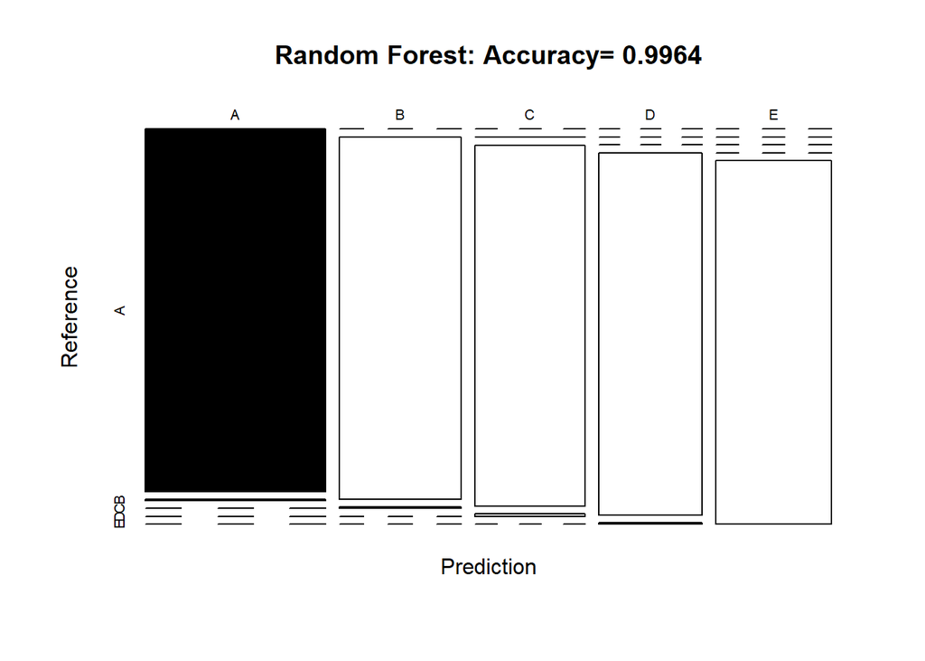

```r
plot(confmatRF$table, col=confmatRF$byClass,
     main=paste("Random Forest: Accuracy=",
                round(confmatRF$overall['Accuracy'],4)))
```

## Decision Trees

Next prediction model to apply is Decision Trees. The function below generates a plot, also displaying the model’s accuracy within the title.

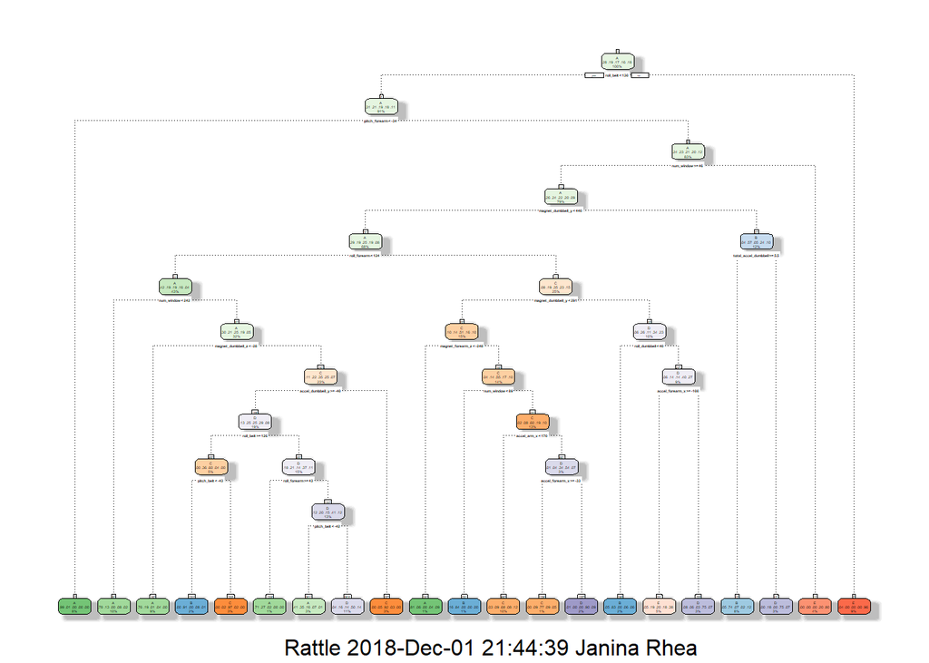

```r
set.seed(12345)
DT <- rpart(classe~., data=s.train, method="class")
fancyRpartPlot(DT)
```

```r
predictDT <- predict(DT, newdata=s.test, type="class")
confmatDT <- confusionMatrix(predictDT, s.test$classe)
confmatDT
```

```
## Confusion Matrix and Statistics
##
##           Reference
## Prediction    A    B    C    D    E
##          A 1530  269   51   79   16
##          B   35  575   31   25   68
##          C   17   73  743   68   84
##          D   39  146  130  702  128
##          E   53   76   71   90  786
##
## Overall Statistics
##
##                Accuracy : 0.7368
##                  95% CI : (0.7253, 0.748)
##     No Information Rate : 0.2845
##     P-Value [Acc > NIR] : < 2.2e-16
##
##                   Kappa : 0.6656
##  Mcnemar's Test P-Value : < 2.2e-16
##
## Statistics by Class:
##
##                      Class: A Class: B Class: C Class: D Class: E
## Sensitivity            0.9140  0.50483   0.7242   0.7282   0.7264
## Specificity            0.9014  0.96650   0.9502   0.9100   0.9396
## Pos Pred Value         0.7866  0.78338   0.7543   0.6131   0.7305
## Neg Pred Value         0.9635  0.89051   0.9422   0.9447   0.9384
## Prevalence             0.2845  0.19354   0.1743   0.1638   0.1839
## Detection Rate         0.2600  0.09771   0.1263   0.1193   0.1336
## Detection Prevalence   0.3305  0.12472   0.1674   0.1946   0.1828
## Balanced Accuracy      0.9077  0.73566   0.8372   0.8191   0.8330
```

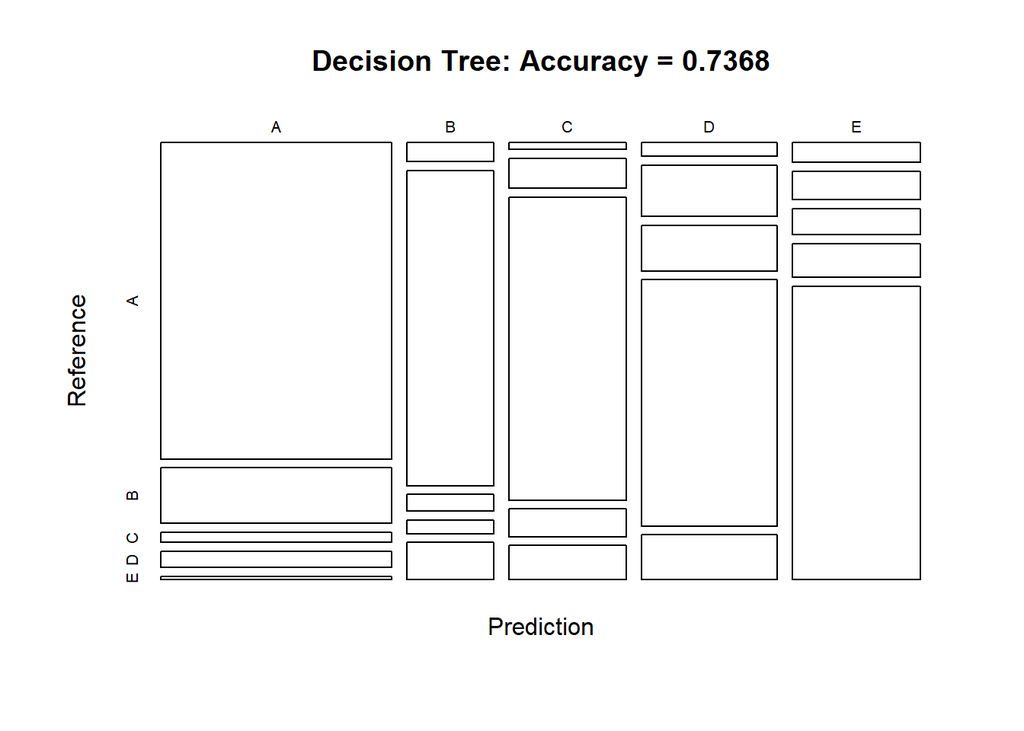

```r
plot(confmatDT$table, col=confmatDT$byClass,
     main=paste("Decision Tree: Accuracy =",
                round(confmatDT$overall['Accuracy'], 4)))
```

## Generalized Boosted Model

```r
set.seed(12345)
conGBM <- trainControl(method="repeatedcv", number=5, repeats=1)
modfitGBM <- train(classe ~., data=s.train, method="gbm",
                   trControl=conGBM, verbose=FALSE)
modfitGBM$finalModel
```

```
## A gradient boosted model with multinomial loss function.
## 150 iterations were performed.
## There were 53 predictors of which 41 had non-zero influence.
```

```r
predictGBM <- predict(modfitGBM, newdata=s.test)
confmatGBM <- confusionMatrix(predictGBM, s.test$classe)
confmatGBM
```

```
## Confusion Matrix and Statistics
##
##           Reference
## Prediction    A    B    C    D    E
##          A 1670   11    0    2    0
##          B    4 1115   16    5    2
##          C    0   12 1006   16    1
##          D    0    1    4  941   10
##          E    0    0    0    0 1069
##
## Overall Statistics
##
##                Accuracy : 0.9857
##                  95% CI : (0.9824, 0.9886)
##     No Information Rate : 0.2845
##     P-Value [Acc > NIR] : < 2.2e-16
##
##                   Kappa : 0.9819
##  Mcnemar's Test P-Value : NA
##
## Statistics by Class:
##
##                      Class: A Class: B Class: C Class: D Class: E
## Sensitivity            0.9976   0.9789   0.9805   0.9761   0.9880
## Specificity            0.9969   0.9943   0.9940   0.9970   1.0000
## Pos Pred Value         0.9923   0.9764   0.9720   0.9843   1.0000
## Neg Pred Value         0.9990   0.9949   0.9959   0.9953   0.9973
## Prevalence             0.2845   0.1935   0.1743   0.1638   0.1839
## Detection Rate         0.2838   0.1895   0.1709   0.1599   0.1816
## Detection Prevalence   0.2860   0.1941   0.1759   0.1624   0.1816
## Balanced Accuracy      0.9973   0.9866   0.9873   0.9865   0.9940
```

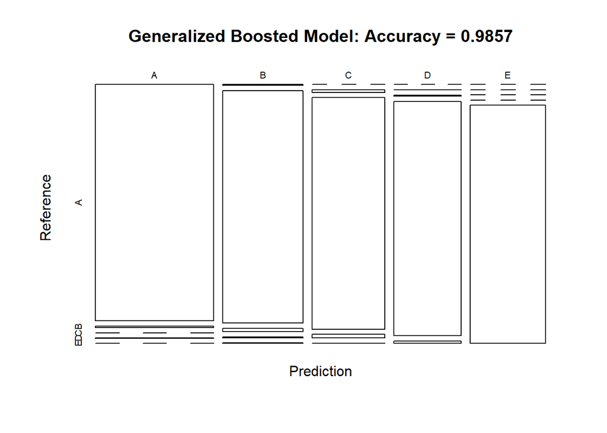

```r
plot(confmatGBM$table, col=confmatGBM$byClass,
     main=paste("Generalized Boosted Model: Accuracy =", round(confmatGBM$overall['Accuracy'], 4)))
```

## Final Model to Use

Comparing the three models, RF results to the highest accuracy, and thus, it will be used in predicting the 20 cases.

```r
pred.test <- predict(RF, newdata=test)
pred.test
```

```
##  [1] B A B A A E D B A A B C B A E E A B B B
## Levels: A B C D E
```